# Problem 1

# Problem 5

In this problem we will refer to the binary classification task depicted in the below figure, which we attempt to solve with the simple linear logistic regression model:

$$ P(y = +1 \mid x,\,\omega_1,\, \omega_2) = \sigma(\omega_1 x_1 + \omega_2 x_2) = \frac{1}{1+\exp(-\omega_1 x_1 - \omega_2 x_2)}$$

(For simplicity we do not use the bias parameter $\omega_0$ or think as $\omega_0 = 0$).

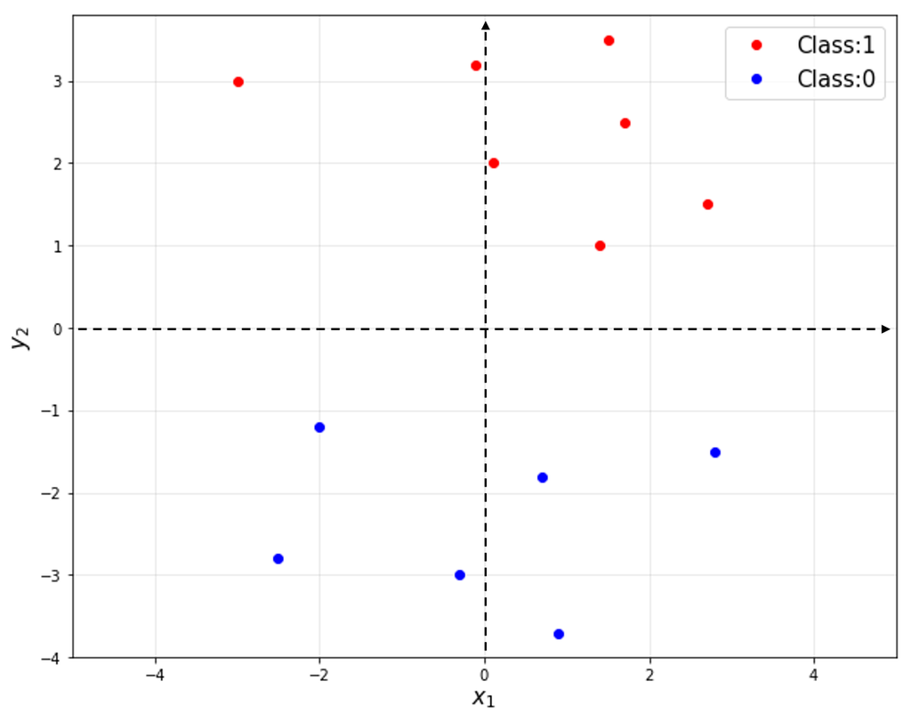

Download files: [logistic_reg_x](https://www.dropbox.com/s/1fvv5vists1yg36/logistic_reg_x.npy?dl=1) and [logistic_reg_y](https://www.dropbox.com/s/z1y3u15gqtcd8vm/logistic_reg_y.npy?dl=1)

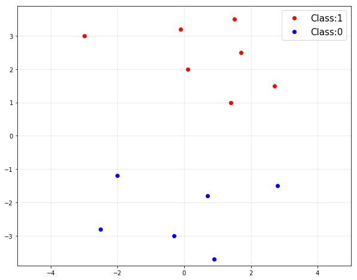

```python
import numpy as np
import cvxpy as cvx
import matplotlib.pyplot as plt
%matplotlib inline

x = np.load("./data_files/logistic_reg_x.npy")
y = np.load("./data_files/logistic_reg_y.npy")

plt.figure(figsize = (10,8))
plt.plot(x[y==1, 0], x[y==1, 1], 'or', label = 'Class:1')
plt.plot(x[y==0, 0], x[y==0, 1], 'ob', label = 'Class:0')
plt.legend(fontsize = 15)
plt.axis('equal')
plt.xlim([-5, 5])
plt.ylim([-5,5])
plt.grid(alpha = 0.3)
plt.show()
```

(a) [3pt] Plot a classification boundary by the logistic regression on the given data points. (Note that $\omega_0 = 0$)

$$ \max \sum_{i=1}^{m} \log P\left( y_i \mid x_i, \, \omega_1, \, \omega_2\right)$$

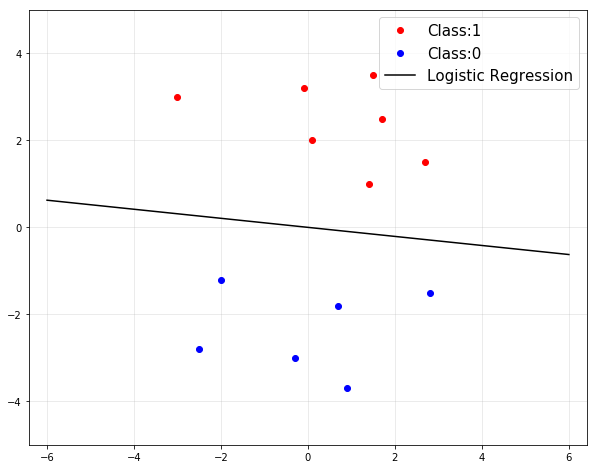

```python
import numpy as np
import cvxpy as cvx
import matplotlib.pyplot as plt
%matplotlib inline

x = np.load("./data_files/logistic_reg_x.npy")
y = np.load("./data_files/logistic_reg_y.npy")

y = np.reshape(y, (-1,1))

x = np.asmatrix(x)
y = np.asmatrix(y)

w = cvx.Variable([2,1])
obj = cvx.Maximize(y.T*x*w - cvx.sum(cvx.logistic(x*w)))
prob = cvx.Problem(obj).solve()

w = w.value

xp = np.linspace(-6,6,100)
yp = -w[0,0]/w[1,0]*xp

x = np.array(x)
y = np.array(y)

plt.figure(figsize = (10,8))
plt.plot(x[y[:,0]==1, 0], x[y[:,0]==1, 1], 'or', label = 'Class:1')
plt.plot(x[y[:,0]==0, 0], x[y[:,0]==0, 1], 'ob', label = 'Class:0')
plt.plot(xp,yp, 'k', label = 'Logistic Regression')
plt.legend(fontsize = 15)
plt.axis('equal')
plt.xlim([-5, 5])
plt.ylim([-5,5])
plt.grid(alpha = 0.3)
plt.show()
```

(b) [6pt] Consider a regularization approach where we want to minimize

$$ \sum_{i=1}^{m} - \log P\left( y_i \mid x_i, \, \omega_1, \, \omega_2\right) + \lambda \,\omega_2^2 $$

This is a logistic regression with regularization. Plot a classification boundary on the given data points. (Note that only $\omega_2$ is penalized. And set $\lambda = 100$) Then explain why the boundary has changed as a result of such regularization.

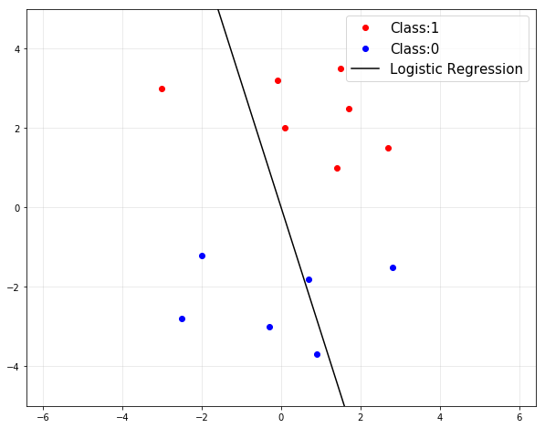

```python
x = np.asmatrix(x)
y = np.asmatrix(y)

lamda = 100

w = cvx.Variable([2,1])
obj = cvx.Minimize(- y.T*x*w + cvx.sum(cvx.logistic(x*w)) + lamda*w[1,0]**2)
prob = cvx.Problem(obj).solve()

w = w.value

xp = np.linspace(-6,6,100)
yp = -w[0,0]/w[1,0]*xp

x = np.array(x)
y = np.array(y)

plt.figure(figsize = (10,8))
plt.plot(x[y[:,0]==1,0], x[y[:,0]==1,1], 'or', label='Class:1')
plt.plot(x[y[:,0]==0,0], x[y[:,0]==0,1], 'ob', label='Class:0')
plt.plot(xp,yp, 'k', label = 'Logistic Regression')
plt.legend(fontsize = 15)
plt.axis('equal')
plt.xlim([-5, 5])
plt.ylim([-5,5])
plt.grid(alpha = 0.3)
plt.show()
```

This regularization term penalizes $\omega_2^2$, which makes it as small as possible.

(c) [6pt] If we change the form of regularization to L1 norm

$$ \min \sum_{i=1}^{m} - \log P\left( y_i \mid x_i,\omega_1, \omega_2\right) + \lambda \,\left( \lvert \omega_1 \rvert + \lvert \omega_2 \rvert \right)$$

This is a logistic regression with regularization. Plot a classification boundary on the given data points. (Note that L1 norm of $\omega$ is penalized. And set $\lambda = 0.1$) Then explain why the boundary has changed as a result of such regularization.

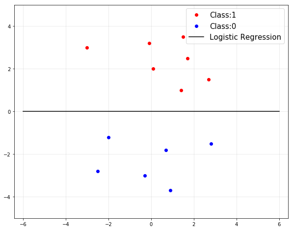

```python
x = np.asmatrix(x)
y = np.asmatrix(y)

lamda = 0.1

w = cvx.Variable([2,1])
obj = cvx.Minimize(- y.T*x*w + cvx.sum(cvx.logistic(x*w)) + lamda*cvx.norm(w,1))
prob = cvx.Problem(obj).solve()

w = w.value

xp = np.linspace(-6,6,100)
yp = -w[0,0]/w[1,0]*xp

x = np.array(x)
y = np.array(y)

plt.figure(figsize = (10,8))
plt.plot(x[y[:,0]==1,0], x[y[:,0]==1,1], 'or', label='Class:1')
plt.plot(x[y[:,0]==0,0], x[y[:,0]==0,1], 'ob', label='Class:0')
plt.plot(xp,yp, 'k', label ='Logistic Regression')
plt.legend(fontsize = 15)
plt.axis('equal')
plt.xlim([-5, 5])
plt.ylim([-5,5])
plt.grid(alpha = 0.3)
plt.show()
```

This regularization term penalizes $\omega$ in a sense of L1 norm, which makes it small and sparse at the same time. It results in $\omega_1 = 0$